# Are Neighborhoods with Public Housing Projects Brighter?(Providence RI)

Naoya Morishita

# Introduction

## Introduction

This exercise will look at brightness values across the city of Providence Rhode Island, and compare the values between grids with and without public housings, referring to [this case study](https://github.com/agroimpacts/USFlite/blob/main/external/notebooks/nightlights-part2.md).

## Datasets

- The Monthly Average [night lights between 2012-2023 from NASA](https://www.earthdata.nasa.gov/learn/backgrounders/nighttime-lights)
- SAVI from the [Landsat8](https://www.usgs.gov/landsat-missions/landsat-8)
- Gridded Population from [the US Census in 2020](https://www.census.gov/topics/population.html)
- Gridded Public Housing Density Estimated from [HUD Data](https://www.huduser.gov/portal/datasets/assthsg.html#2009-2022_data) & Building Footprint Data from [URI Environmental Data Center and RIGIS](https://www.rigis.org/datasets/building-footprints/explore)
- Gridded Building Density Data of Building Footprint Data from [URI Environmental Data Center and RIGIS](https://www.rigis.org/datasets/building-footprints/explore)(https://www.sciencebase.gov/catalog/item/5d27a8dfe4b0941bde650fc7)

# Data Preparation

## Reading & Showing Data

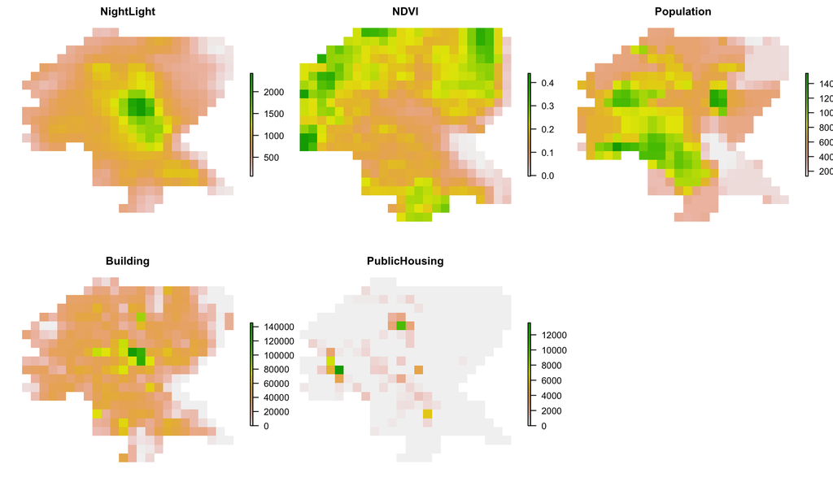

```r
# Plotting the Raster====
plot_noaxes(b)
```